# 프로야구 <MVP & 골든 글러브> 수상자 예측 모델

이학민 이지원 김호성 최호식

10/3/2019

## **개요**

##### 흔히 우리는 성적이 좋은 선수가 MVP 및 골든 글러브를 받을 것이라고 예상하지만 실제로는 성적이 조금 떨어짐에도 불구하고 수상하는 선수들이 등장하여 야구팬들 사이에 크게 논란이 되고는 한다. 그 이유로 우리 조가 주목한 부분은 기자들이 투표를 하기 때문에 성적에 비해 언론에 많이 노출되거나 인기가 많은 선수들이 받기도 한다는 것이다. 따라서 우리는 성적 요인에 기자단 투표 성향에 가중치를 주어 정확한 예측 모델을 만들고자 한다.

### **독립 변수**

##### 성적 + 야구 기사 데이터 크롤링을 통한 가중치

### **최근 5년 간 MVP & 골든 글러브 수상자들**

1. MVP

| 연도 | 이름 | 포지션 | 기록 |
| --- | --- | --- | --- |
| 2018 | 김재환 | 외야수 | 타율 0.334 장타율 0.657(2위) 출루율 0.405 |
| 2017 | 양현종 | 투수 | 158탈삼진(3위), 평균자책점 3.44(5위), 승률 0.768(2위) |
| 2016 | 더스틴 니퍼트 | 투수 | 142탈삼진, 평균자책점 2.95, 승률 0.880 |
| 2015 | 에릭 테임즈 | 1루수 | 타율 0.381, 장타율 0.790, 출루율 0.497 2루타 42개 103볼넷(2위) |
| 2014 | 서건창 | 2루수 | 타율 0.370, 장타율 0.547, 출루율 0.438(4위) 2루타 41개 3루타 17개 |

[출처: KBO MVP 나무위키](https://namu.wiki/w/KBO%20MVP)

2. 골든 글러브

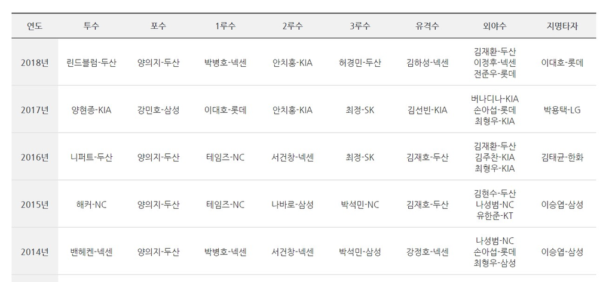

   [출처: KBO공식홈페이지-역대 골든글러브](https://www.koreabaseball.com/History/Etc/GoldenGlove.aspx)

### **모델 계획**

1. 자료
- KBO 골든 글러브
  - 후보 선정 기준이 존재한다. 자세한 내용은 링크 참조 [KBO 골든글러브_2.골든글러브 후보 선정 기준](https://namu.wiki/w/KBO%20%EA%B3%A8%EB%93%A0%EA%B8%80%EB%9F%AC%EB%B8%8C#s-2)
  - 포지션 별 역대 수상자 명단 및 성적 [KBO 골든글러브 역대 수상자, 나무위키](https://namu.wiki/w/KBO%20%EA%B3%A8%EB%93%A0%EA%B8%80%EB%9F%AC%EB%B8%8C%20%EC%97%AD%EB%8C%80%20%EC%88%98%EC%83%81%EC%9E%90)
2. 모델 예상
- 과겨 년도 중 선정 기준에 해당 되는 선수 후보 명단을 추출 한다.
- 해당 년도의 언론사 별 KBO 관련 기사 들을 스크랩 한 후, 명단에 오른 이름을 스캔하여 얼마나 언급되는지 횟수를 기록한다.
- 추가로 긍정적인 단어들과 부정적인 단어 (명사, 형용사)도 이름과 상관해서 스캔 작업 후 이름과 긍정/부정의 척도를 더미 변수 1과 0으로 책정 후 후보자들 간 비교를 한다.